# Practical Machine Learning Course Project

George Ng

25/01/2017

## Practical Machine Learning Project : Prediction Assignment Writeup

## Executive Summary

This R Markdown shows both the R code and results of the Practical Machine Learning Course Project in a HTML file processed by knitr. Devices such as Jawbone Up, Nike FuelBand, and Fitbit enable the collection of a large amount of gym activity data. The data is collected from accelerometers on the belt, forearm, arm, and dumbell of 6 participants. The outcome variable has five classes and the total number of predictors are 159. The machine learning algorithm described here is applied to the 20 test cases in the test data for a seperate Course Project Prediction quiz and the predictions are submitted for grading.

## Data Loading and Exploratory Analysis

## Loading the data

The training data for this project are downloaded from [here][https://d396qusza40orc.cloudfront.net/predmachlearn/pml-training.csv]

The test data are downloaded from [here][https://d396qusza40orc.cloudfront.net/predmachlearn/pml-testing.csv]

The data for this project come from this [source][http://groupware.les.inf.puc-rio.br/har]

```r
training <- read.csv("./data/pml-training.csv")
testing <- read.csv("./data/pml-testing.csv")
inTrain  <- createDataPartition(training$classe, p=0.7, list=FALSE)
TrainSet <- training[inTrain, ]
TestSet  <- training[-inTrain, ]
```

After downloading the data from the data source, we can read the two csv files into two data frames.

```r
NZV <- nearZeroVar(TrainSet)
TrainSet <- TrainSet[, -NZV]
TestSet  <- TestSet[, -NZV]
dim(TrainSet); dim(TestSet)
```

```
## [1] 13737   106
```

```
## [1] 5885  106
```

The training data set contains 19622 observations and 160 variables, while the testing data set contains 20 observations and 160 variables. The “classe” variable in the training set is the outcome to predict.

## Clean The Data

In this step, we will clean the data and get rid of observations with missing values as well as some meaningless variables.

```r
AllNA    <- sapply(TrainSet, function(x) mean(is.na(x))) > 0.95
TrainSet <- TrainSet[, AllNA==FALSE]
TestSet  <- TestSet[, AllNA==FALSE]
dim(TrainSet)
```

```
## [1] 13737    59
```

First, we remove columns that contain NA missing values, i.e. are unnessary.

```r
TrainSet <- TrainSet[, -(1:5)]
TestSet  <- TestSet[, -(1:5)]
dim(TrainSet); dim(TestSet)
```

```
## [1] 13737    54
```

```
## [1] 5885   54
```

Verifying Correlation Analysis

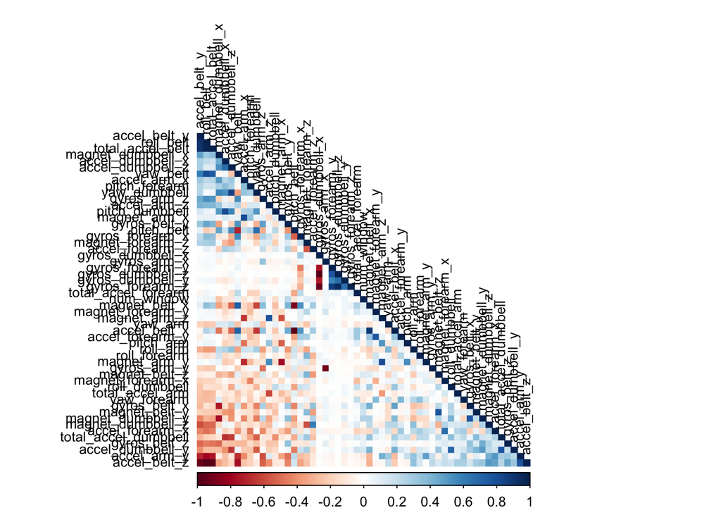

```r
corMatrix <- cor(TrainSet[, -54])
corrplot(corMatrix, order = "FPC", method = "color", type = "lower",
         tl.cex = 0.8, tl.col = rgb(0, 0, 0))
```

## Slice the data

Then, we can split the cleaned training set into a pure training data set (70%) and a validation data set (30%). We will use the validation data set to conduct cross validation in future steps.

Random Forest

```r
set.seed(12345)
controlRF <- trainControl(method="cv", number=3, verboseIter=FALSE)
modFitRandForest <- train(classe ~ ., data=TrainSet, method="rf",
                          trControl=controlRF)
modFitRandForest$finalModel
```

```
##
## Call:
##  randomForest(x = x, y = y, mtry = param$mtry)
##                Type of random forest: classification
##                      Number of trees: 500
## No. of variables tried at each split: 27
##
##         OOB estimate of  error rate: 0.21%
## Confusion matrix:
##      A    B    C    D    E  class.error
## A 3905    0    0    0    1 0.0002560164
## B    7 2646    4    1    0 0.0045146727
## C    0    5 2390    1    0 0.0025041736
## D    0    0    5 2247    0 0.0022202487
## E    0    0    0    5 2520 0.0019801980
```

## Data Modeling

Then, we estimate the performance of the model on the validation data set. Predict on test dataset

```r
predictRandForest <- predict(modFitRandForest, newdata=TestSet)
confMatRandForest <- confusionMatrix(predictRandForest, TestSet$classe)
confMatRandForest
```

```
## Confusion Matrix and Statistics
##
##           Reference
## Prediction    A    B    C    D    E
##          A 1673    0    0    0    0
##          B    1 1138    0    0    0
##          C    0    1 1026    1    0
##          D    0    0    0  962    2
##          E    0    0    0    1 1080
##
## Overall Statistics
##
##                Accuracy : 0.999
##                  95% CI : (0.9978, 0.9996)
##     No Information Rate : 0.2845
##     P-Value [Acc > NIR] : < 2.2e-16
##
##                   Kappa : 0.9987
##  Mcnemar's Test P-Value : NA
##
## Statistics by Class:
##
##                      Class: A Class: B Class: C Class: D Class: E
## Sensitivity            0.9994   0.9991   1.0000   0.9979   0.9982
## Specificity            1.0000   0.9998   0.9996   0.9996   0.9998
## Pos Pred Value         1.0000   0.9991   0.9981   0.9979   0.9991
## Neg Pred Value         0.9998   0.9998   1.0000   0.9996   0.9996
## Prevalence             0.2845   0.1935   0.1743   0.1638   0.1839
## Detection Rate         0.2843   0.1934   0.1743   0.1635   0.1835
## Detection Prevalence   0.2843   0.1935   0.1747   0.1638   0.1837
## Balanced Accuracy      0.9997   0.9995   0.9998   0.9988   0.9990
```

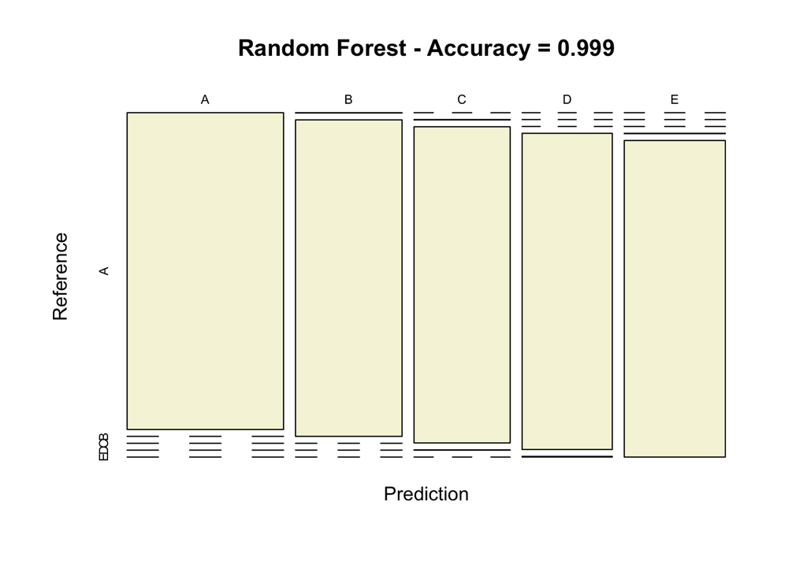

```r
plot(confMatRandForest$table, col = "beige",
     main = paste("Random Forest - Accuracy =",
                  round(confMatRandForest$overall['Accuracy'], 4)))
```

## Decision Trees Method

[figure not shown]

```r
set.seed(12345)
modFitDecTree <- rpart(classe ~ ., data=TrainSet, method="class")
suppressWarnings(fancyRpartPlot(modFitDecTree))
```

# Test on Test dataset

```r
predictDecTree <- predict(modFitDecTree, newdata=TestSet, type="class")
confMatDecTree <- confusionMatrix(predictDecTree, TestSet$classe)
confMatDecTree
```

```
## Confusion Matrix and Statistics
##
##           Reference
## Prediction    A    B    C    D    E
##          A 1497  278   46  107   95
##          B   49  595   40   24  100
##          C   11   69  863  128   70
##          D   95  156   59  664  115
##          E   22   41   18   41  702
##
## Overall Statistics
##
##                Accuracy : 0.7342
##                  95% CI : (0.7228, 0.7455)
##     No Information Rate : 0.2845
##     P-Value [Acc > NIR] : < 2.2e-16
##
##                   Kappa : 0.6618
##  Mcnemar's Test P-Value : < 2.2e-16
##
## Statistics by Class:
##
##                      Class: A Class: B Class: C Class: D Class: E
## Sensitivity            0.8943   0.5224   0.8411   0.6888   0.6488
## Specificity            0.8751   0.9551   0.9428   0.9136   0.9746
## Pos Pred Value         0.7400   0.7364   0.7564   0.6097   0.8519
## Neg Pred Value         0.9542   0.8929   0.9656   0.9374   0.9249
## Prevalence             0.2845   0.1935   0.1743   0.1638   0.1839
## Detection Rate         0.2544   0.1011   0.1466   0.1128   0.1193
## Detection Prevalence   0.3438   0.1373   0.1939   0.1850   0.1400
## Balanced Accuracy      0.8847   0.7388   0.8920   0.8012   0.8117
```

Ploting Matrix Results

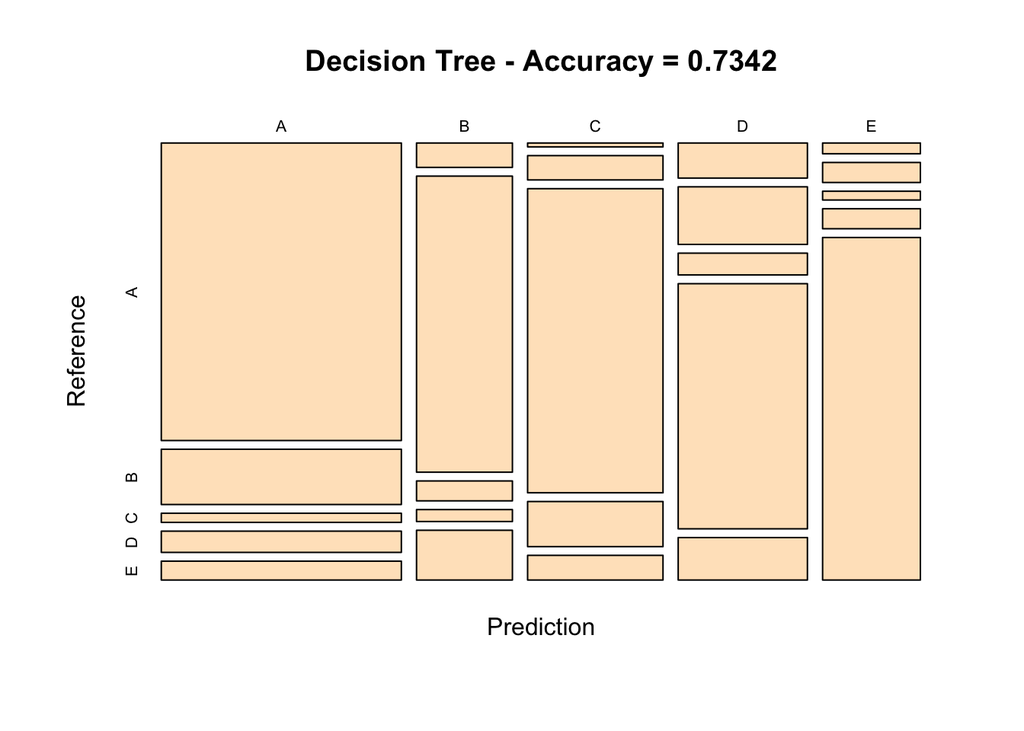

```r
plot(confMatDecTree$table, col = "bisque",
     main = paste("Decision Tree - Accuracy =",
                  round(confMatDecTree$overall['Accuracy'], 4)))
```

# General Boasted Model

```r
set.seed(12345)
controlGBM <- trainControl(method = "repeatedcv", number = 5, repeats = 1)
modFitGBM  <- train(classe ~ ., data=TrainSet, method = "gbm",
                    trControl = controlGBM, verbose = FALSE)
modFitGBM$finalModel
```

```
## A gradient boosted model with multinomial loss function.
## 150 iterations were performed.
## There were 53 predictors of which 45 had non-zero influence.
```

Predict on test dataset for GBM

```r
predictGBM <- predict(modFitGBM, newdata=TestSet)
confMatGBM <- confusionMatrix(predictGBM, TestSet$classe)
confMatGBM
```

```
## Confusion Matrix and Statistics
##
##           Reference
## Prediction    A    B    C    D    E
##          A 1666    8    0    0    0
##          B    8 1110    3    3    7
##          C    0   21 1020    5    1
##          D    0    0    3  955   16
##          E    0    0    0    1 1058
##
## Overall Statistics
##
##                Accuracy : 0.9871
##                  95% CI : (0.9839, 0.9898)
##     No Information Rate : 0.2845
##     P-Value [Acc > NIR] : < 2.2e-16
##
##                   Kappa : 0.9837
##  Mcnemar's Test P-Value : NA
##
## Statistics by Class:
##
##                      Class: A Class: B Class: C Class: D Class: E
## Sensitivity            0.9952   0.9745   0.9942   0.9907   0.9778
## Specificity            0.9981   0.9956   0.9944   0.9961   0.9998
## Pos Pred Value         0.9952   0.9814   0.9742   0.9805   0.9991
## Neg Pred Value         0.9981   0.9939   0.9988   0.9982   0.9950
## Prevalence             0.2845   0.1935   0.1743   0.1638   0.1839
## Detection Rate         0.2831   0.1886   0.1733   0.1623   0.1798
## Detection Prevalence   0.2845   0.1922   0.1779   0.1655   0.1799
## Balanced Accuracy      0.9967   0.9851   0.9943   0.9934   0.9888
```

Plot matrix result

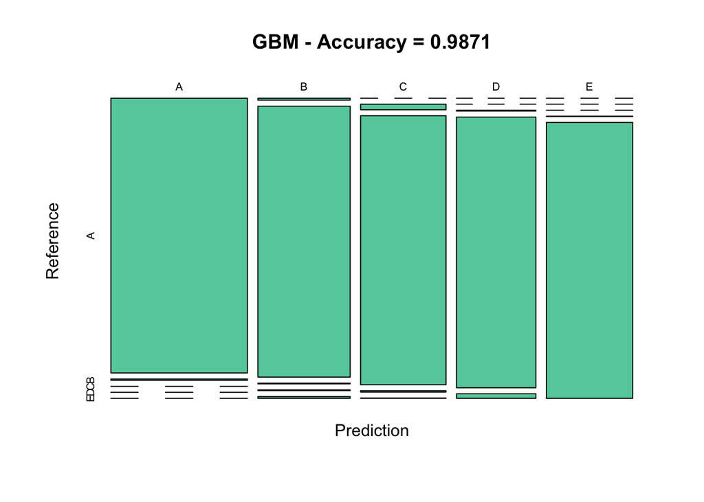

```r
plot(confMatGBM$table, col = "aquamarine3",
     main = paste("GBM - Accuracy =", round(confMatGBM$overall['Accuracy'], 4)))
```

## Cross Validationi Model

Data Preparation

```r
training<-read.csv("./data/pml-training.csv",na.strings=c("NA","#DIV/0!"))
testing<-read.csv("./data/pml-testing.csv",na.strings=c("NA","#DIV/0!"))
table(training$classe)
```

```
##
##    A    B    C    D    E
## 5580 3797 3422 3216 3607
```

```r
NA_Count = sapply(1:dim(training)[2],function(x)sum(is.na(training[,x])))
NA_list = which(NA_Count>0)
colnames(training[,c(1:7)])
```

```
## [1] "X"                    "user_name"            "raw_timestamp_part_1"
## [4] "raw_timestamp_part_2" "cvtd_timestamp"       "new_window"
## [7] "num_window"
```

```r
training = training[,-NA_list]
training = training[,-c(1:7)]
training$classe = factor(training$classe)
testing = testing[,-NA_list]
testing = testing[,-c(1:7)]
```

```r
set.seed(1234)
cv3 = trainControl(method="cv",number=3,allowParallel=TRUE,verboseIter=TRUE)
modrf = train(classe~., data=training, method="rf",trControl=cv3)
modtree = train(classe~.,data=training,method="rpart",trControl=cv3)
prf=predict(modrf,training)
ptree=predict(modtree,training)
table(prf,training$classe); table(ptree,training$classe)
```

```
##
## prf    A    B    C    D    E
##   A 5580    0    0    0    0
##   B    0 3797    0    0    0
##   C    0    0 3422    0    0
##   D    0    0    0 3216    0
##   E    0    0    0    0 3607
```

```
##
## ptree    A    B    C    D    E
##     A 5080 1581 1587 1449  524
##     B   81 1286  108  568  486
##     C  405  930 1727 1199  966
##     D    0    0    0    0    0
##     E   14    0    0    0 1631
```

```r
prf=predict(modrf,testing)
ptree=predict(modtree,testing)
table(prf,ptree)
```

```
##    ptree
## prf A B C D E
##   A 7 0 0 0 0
##   B 3 0 5 0 0
##   C 0 0 1 0 0
##   D 0 0 1 0 0
##   E 1 0 2 0 0
```

Random forest model has the best accuracy for testing datas

## Conclusion

```r
answers=predict(modrf,testing)
pml_write_files = function(x){
  n = length(x)
  for(i in 1:n){
    filename = paste0("problem_id_",i,".txt")
    write.table(x[i],file=filename,quote=FALSE,row.names=FALSE,col.names=FALSE)
  }
}
answers
```

```
##  [1] B A B A A E D B A A B C B A E E A B B B
## Levels: A B C D E
```

pml_write_files(answers)

The predicted classes for the 20 tests are: B A B A A E D B A A B C B A E E A B B B.